# Lab 04: Wine Quality System

Author

Afnan Dzaharudin

Published

February 26, 2024

## Introduction

A [sommelier](https://en.m.wikipedia.org/wiki/Sommelier) is an individual who is thoroughly trained with the knowledge of wine, arguably a staple in Western fine dining. They also [get paid a median of $63,000 dollars for their work!](https://www.salary.com/research/salary/benchmark/sommelier-salary). Lacking the cost to hire one for our purposes, could we instead assess the quality of wines based on their chemical properties? It would save costs and time, *and* it’s possibly quite easy to streamline the process of measuring these mentioned properties for future wines.

## Methods

```python
# imports
import pandas as pd
import numpy as np
import matplotlib.pyplot as plt
import seaborn as sns
sns.set_theme(style='darkgrid')

from sklearn.pipeline import Pipeline
from sklearn.impute import SimpleImputer
from sklearn.preprocessing import StandardScaler, OneHotEncoder, PolynomialFeatures
from sklearn.compose import ColumnTransformer
from sklearn.model_selection import GridSearchCV

from sklearn.neighbors import KNeighborsClassifier, KNeighborsRegressor
from sklearn.linear_model import LogisticRegression, LinearRegression, Lasso, Ridge
from sklearn.tree import DecisionTreeClassifier, DecisionTreeRegressor

# show me ALL the plots!
from IPython.display import display

from joblib import dump
```

### Data

```python
# load data
wine_train = pd.read_csv("https://cs307.org/lab-04/data/wine-train.csv")

# display data
wine_train
```

Table 1: First and last five rows of the `wine_train` dataset

|  | fixed acidity | volatile acidity | citric acid | residual sugar | chlorides | free sulfur dioxide | total sulfur dioxide | density | pH | sulphates | alcohol | quality | color |
| --- | --- | --- | --- | --- | --- | --- | --- | --- | --- | --- | --- | --- | --- |
| 0 | 6.6 | 0.240 | 0.35 | 7.70 | 0.031 | 36.0 | 135.0 | 0.99380 | 3.19 | 0.37 | 10.5 | 5 | white |
| 1 | 8.3 | 0.280 | 0.48 | 2.10 | 0.093 | 6.0 | 12.0 | 0.99408 | 3.26 | 0.62 | 12.4 | 7 | red |
| 2 | 7.7 | 0.715 | 0.01 | 2.10 | 0.064 | 31.0 | 43.0 | 0.99371 | 3.41 | 0.57 | 11.8 | 6 | red |
| 3 | 5.2 | 0.370 | 0.33 | 1.20 | 0.028 | 13.0 | 81.0 | 0.99020 | 3.37 | 0.38 | 11.7 | 6 | white |
| 4 | 6.6 | 0.260 | 0.56 | 15.40 | 0.053 | 32.0 | 141.0 | 0.99810 | 3.11 | 0.49 | 9.3 | 5 | white |
| ... | ... | ... | ... | ... | ... | ... | ... | ... | ... | ... | ... | ... | ... |
| 5192 | 7.6 | 0.320 | 0.58 | 16.75 | 0.050 | 43.0 | 163.0 | 0.99990 | 3.15 | 0.54 | 9.2 | 5 | white |
| 5193 | 5.6 | 0.280 | 0.27 | 3.90 | 0.043 | 52.0 | 158.0 | 0.99202 | 3.35 | 0.44 | 10.7 | 7 | white |
| 5194 | 6.4 | 0.370 | 0.20 | 5.60 | 0.117 | 61.0 | 183.0 | 0.99459 | 3.24 | NaN | 9.5 | 5 | white |
| 5195 | 6.5 | 0.260 | 0.50 | NaN | 0.051 | 46.0 | 197.0 | 0.99536 | 3.18 | 0.47 | 9.5 | 5 | white |
| 5196 | 7.2 | 0.620 | 0.06 | 2.70 | 0.077 | 15.0 | 85.0 | 0.99746 | 3.51 | 0.54 | 9.5 | 5 | red |

5197 rows × 13 columns

Our dataset is sourced from [a paper](https://doi.org/10.1016/j.dss.2009.05.016) by Cortez, P., Cerdeira, A., Almeida, F., Matos, T., & Reis, J. (2009), which is also alternatively available from the [UC Irvine Machine Learning Repository](https://archive.ics.uci.edu/dataset/186/wine+quality). The measures in this dataset are sampled from Portuguese “Vinho Verde” wine, a product from the Minho (northwest) region of Portugal.

Listed below are our target and features:

Table 2: Descriptions for Each Variable

[output not shown]

#### Summary Statistics

```python
{"# Samples": wine_train.shape[0],
 "# Features": wine_train.columns.size - 1}
```

```
{'# Samples': 5197, '# Features': 12}
```

```python
pd.DataFrame(wine_train['quality'].value_counts()).sort_values('quality')
```

Table 3: Counts of Occurrences of each Quality Value

| quality | count |
| --- | --- |
| 3 | 24 |
| 4 | 173 |
| 5 | 1736 |
| 6 | 2239 |
| 7 | 864 |
| 8 | 157 |
| 9 | 4 |

#### Visualizations

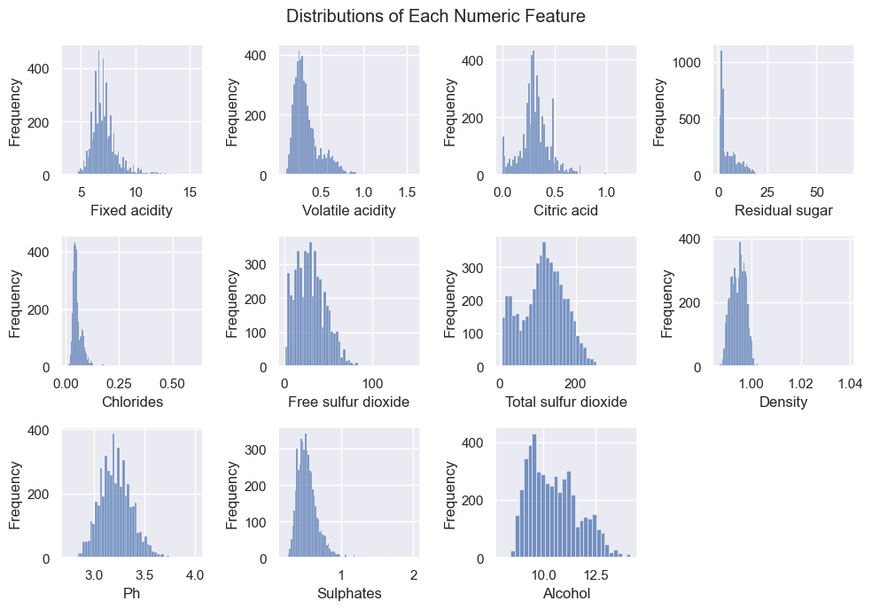

Figure 1: Distributions of Each Numeric Feature

```python
nrow = 3
ncol = 4
cats = wine_train.drop("quality", axis=1).dtypes.keys()
types = wine_train.drop("quality", axis=1).dtypes.values
colors = wine_train['color'].unique().tolist()
fig_colors = ['gold', 'firebrick'] # Teehee

fig, axs = plt.subplots(nrow, ncol, figsize=(10, 7))

for i, ax in enumerate(axs.flatten()):
    if (types[i] in ['float64', 'int64']): # Is it numeric? Make a histogram!
        sns.histplot(wine_train[cats[i]], ax=ax)
    else: # Do nothing
        ax.set_visible(False)

    # General settings
    # sns.despine(ax=ax)
    ax.set_ylabel('Frequency')
    ax.set_xlabel(cats[i].capitalize())

fig.suptitle("Distributions of Each Numeric Feature")
fig.tight_layout()
```

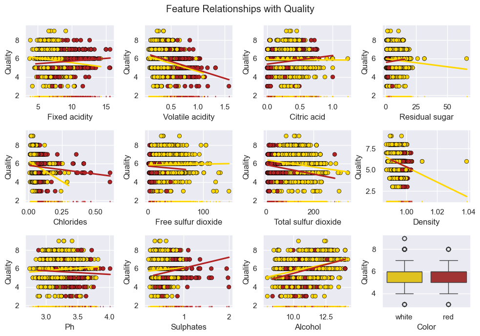

Figure 2: Feature Relationships with Quality

```python
nrow = 3
ncol = 4
cats = wine_train.drop("quality", axis=1).dtypes.keys()
types = wine_train.drop("quality", axis=1).dtypes.values
colors = wine_train['color'].unique().tolist()
fig_colors = ['gold', 'firebrick'] # Teehee

fig, axs = plt.subplots(nrow, ncol, figsize=(10, 7))

for i, ax in enumerate(axs.flatten()):
    if (types[i] in ['float64', 'int64']): # Is it numeric? Make a scatterplot!
        sns.scatterplot(wine_train, y='quality', x = cats[i], hue='color', ax=ax,
                        palette=fig_colors, edgecolor='black', legend=False)
        sns.rugplot(wine_train, x=cats[i], hue='color', ax=ax,
                        palette=fig_colors, legend=False)
        for j, clr in enumerate(colors):
            sns.regplot(wine_train[wine_train['color'] == clr], ci = False,
                        x=cats[i], y='quality', color=fig_colors[j], ax=ax, scatter=False)
    else: # Is it categorical? Plot a boxplot!
        sns.boxplot(wine_train, y='quality', hue=cats[i], x=cats[i], ax=ax, palette=fig_colors, legend=False)

    # General settings
    # sns.despine(ax=ax)
    ax.set_ylabel('Quality')
    ax.set_xlabel(cats[i].capitalize())

fig.suptitle("Feature Relationships with Quality")
fig.tight_layout()
```

We have sampled 5197 different wines and have 12 different features to use in our modelling. We should highlight from Table 3 that we do *not* have the full possible range of quality values. 9 is the highest quality value, and there are no wines ranked 2 or lower. If we were to treat `quality` as a category, we should be wary that we have an imbalance in category counts.

From Figure 1, a few things are worth pointing out. `Total sulfur dioxide` and `Alcohol` are possibly bimodal, due to having two peaks in its distribution. `Volatile acidity` and `Residual sugar` have a lot of data points toward the right, which could indicate skewness. We should be cautious if we choose to use a predictive model that assumes our data is normally distributed.

From Figure 2, we try to see if there are any features that have strong relationships with `Quality`. This is largely *not* the case. Additionally, there isn’t a strong association between `white` and `red` wines for many of these features, besides perhaps `Chlorides`. There isn’t even a strong association between `Color` and `Quality`. So at least in terms of direct relationships, it’ll be hard to find any. Maybe there will be more in the higher dimensions, but plotting that is outside of our scope (also t-SNE calculations take forever).

### Models

```python
# process data for ML
X_train = wine_train.drop("quality", axis=1)
y_train = wine_train["quality"]

numeric_cols = X_train.select_dtypes("number").columns
categorical_cols = X_train.select_dtypes("object").columns

numeric_transformer = Pipeline(
    [
        ("imputer", SimpleImputer()),
        ("scaler", StandardScaler()),
        ("poly", PolynomialFeatures(include_bias=False))
    ]
)

categorical_transformer = Pipeline(
    [
        ("imputer", SimpleImputer(strategy="most_frequent")),
        ("onehot", OneHotEncoder(handle_unknown="ignore"))
    ]
)

preprocessor = ColumnTransformer(
    [
        ("numeric_tf", numeric_transformer, numeric_cols),
        ("categorical_tf", categorical_transformer, categorical_cols)
    ]
)
```

```python
pipeline = Pipeline([
    ("preprocessor", preprocessor),
    ("model", KNeighborsClassifier())
])

param_grid = {
    "preprocessor__numeric_tf__poly__degree": [1, 2],
    "preprocessor__numeric_tf__poly__interaction_only": [True, False],
    "model__n_neighbors":np.arange(5, 20, 1),
}

grid_search = GridSearchCV(pipeline, param_grid, cv=4, scoring="neg_mean_absolute_error")
```

```python
# train models
_ = grid_search.fit(X_train, y_train)
```

We tried many regressors and classifiers, chiefly logistic regression with various solvers, linear, LASSO, and Ridge regression, and decision trees. These all gave a mean absolute error between `0.51` to `0.58`. Ultimately we found the `KNeighborsClassifer` to perform best, as we will see.

## Results

```python
# report model metrics
grid_search.best_score_, grid_search.best_params_
```

```
(-0.5077946053177,
 {'model__n_neighbors': 18,
  'preprocessor__numeric_tf__poly__degree': 1,
  'preprocessor__numeric_tf__poly__interaction_only': True})
```

## Discussion

Being off by about `0.5` is not bad! Especially given that `quality` technically increases in steps of `1`. We should note that, since there are no wines with quality levels 0, 1, 2, or 10, our predictor will never classify wines of that quality either.

Can, or should, a predictive model fully substitute a sommelier? Probably not! Tastes change, and wine variety is likely complex enough that it’d be a poor idea to suggest the one same best wine to every consumer. A human sommelier is likely to be more capable of making tailored suggestions based on a customer’s preferences.

It should also be noted again that our dataset only contains measurements for “Vinho Verde” wine, so this model may not hold so accurate for other types out there.

### Conclusion

A K-nearest neighbors classifier than uses $k=18$ neighbors can make a fairly good predictor for the quality of a Vinho Verde wine. If the goal is just to assess the quality of new Vinho Verde wines, then this model will work great! We caution against using it with other types of wines, as this model is not trained on anything other than Vinho Verde. We also caution against using it to suggest wines to customers, as that is a more nuanced subject that may be better in the hands of a sommelier or a more complex machine learning model.